# Webtoons Project

Tonia Wu

# Introduction

## What are Webtoons?

Webtoons are a type of digital comic from South Korea designed for vertical scrolling on computers and mobile devices. They are often published in full color and may feature music and animations. For the purposes of this project, we will be specifically looking at the comics on Naver Webtoon.

[figure not shown]

Webtoons Originals, which for the sake of brevity we will refer to as “webtoons,” first start on the Discover section of the platform. Anyone can upload to Discover; once a comic is discovered by Webtoon’s editors and the artist agrees to a contract, it will move to the Originals.

## Webtoon Styles

This project aims to find a connection between a webtoon’s art style and variables such as its performance (such as likes and views), genre, and upload schedule.

To give some background on the various art styles creators use, I’ve divided each webtoon into one of several styles:

## Standard

[figure not shown]

Wished You Were Dead

## Simplified Cartoon

[figure not shown]

Supersonic Girl

The simplified cartoon/comic style covers art styles that mimic that of TV animation. They often simplify their characters into highly readable shapes and use a wider variety of line weights than the standard style does. Many also include brighter and wackier color palettes, as well as textured brushes.

## Realistic Standard

[figure not shown]

Covenant

This style is in between the standard and American styles in that it generally includes fingernails, nostrils, blunter jaws, teeth, gums, etc. There are more variations in nose shapes and a tendency to have smaller, more proportionate eyes.

## American

[figure not shown]

The Strange Tales of Oscar Zahn

## Korean Realism

[figure not shown]

True Beauty

# Loading Data

For this project, we wil be working with data from the English platform of Webtoons. The file is from Kaggle: https://www.kaggle.com/datasets/iridazzle/webtoon-originals-datasets.

Webtoons do not come with information on their art style or their author’s country of origin, so I had to manually input them.

The raw file contains data on the genre, authors, weekdays uploaded, number of free episodes, subscriber count, views, likes, upload status, and the synopsis:

```r
rawdata <- read.csv('webtoon_originals_en.csv')
```

```r
head(rawdata)
```

|  | title_id | title | style | original.platform | genre | authors | weekdays | length | subscribers | rating | views | likes | status | daily_pass | synopsis |
| --- | --- | --- | --- | --- | --- | --- | --- | --- | --- | --- | --- | --- | --- | --- | --- |
| 1 | 3766 | 100 | realistic standard | Korean | ACTION | Hyeong Eun,Yunyeol Choi | SUNDAY | 13 | 109568 | 9.18 | 827013 | 86431 | ONGOING | FALSE | Armed only with a gun and a frying pan, Hoyoung Cheon must survive Battlegrounds: a battle-royale style game with 100 participants, where there’s only one way to win: kill the 99 other players, all of… |
| 2 | 1217 | 1000 | American | English | ACTION | Chuck Brown,Sanford Greene | THURSDAY | 20 | 104855 | 8.99 | 1444572 | 80168 | COMPLETED | FALSE | Set in a modern world of aliens, warlocks, zombies, and ancient beasts, "1000" follows Dragon Son - a supreme entity who’s abandoned all creation as he struggles to return to his true Dragon form by c… |
| 3 | 1193 | #Blessed | American | English | DRAMA | M. Victoria Robado | FRIDAY | 64 | 423396 | 9.19 | 19989806 | 1720168 | HIATUS | FALSE | Joanna is a mid-twenties office girl who likes social media and watered down coffee. While griping about her love life, she accidentally swiped right on a whole Pantheon of Gods and Goddesses! Looking… |
| 4 | 1971 | #Killstagram | realistic standard | Korean | THRILLER | Ryoung | SATURDAY | 44 | 870587 | 9.32 | 39281698 | 3498815 | HIATUS | FALSE | Remi Do has everything -- she's super pretty, has the best brand sponsorships on social media, and gets 10,000 likes within seconds of posting a selfie. Oh, and she also has a serial-killing stalker f… |
| 5 | 71 | 10th Dimension Boys | cartoon | English | COMEDY | Cutbu | TUESDAY,WEDNESDAY,THURSDAY | 119 | 93215 | 9.34 | 27986110 | 801533 | COMPLETED | FALSE | In another dimension, anything can happen in your daily life. Absurdly funny, the boys from the 10th dimension are up to no good again. |
| 6 | 3235 | 11 of Me | American | Korean | SUPERNATURAL | Jiae Go,Jaeyeong Yeong | MONDAY,TUESDAY,WEDNESDAY,THURSDAY,FRIDAY,SATURDAY,SUNDAY | 7 | 102268 | 8.83 | 1407074 | 195701 | COMPLETED | TRUE | To Gibeom’s surprise, the mechanical calculator he bought working at a junkyard turns out to be a time machine! With the time machine, he sets out to find and bring together his past selves. Currently… |

# Data Cleaning

Here are the steps I took to prepare the data.

- Cleaning the names

```r
webtoons <- rawdata %>%
  clean_names()
```

- Adding a new variable called `synopsis_length` to quantify the `synopsis`, since I’m curious if it will make an impact

```r
webtoons <- webtoons %>%
  mutate(synopsis_length = str_count(synopsis))
```

- Dropping unhelpful variables, such as `title_id`

```r
webtoons <- webtoons%>%
  dplyr::select(-c(authors, title_id, synopsis))
```

- Renaming the length column to the more descriptive ‘free_episodes’ to avoid confusion:

```r
webtoons <- webtoons %>%
  rename(free_episodes = length)
```

# Exploratory Data Analysis

Naver first began publishing webtoons in 2004 and started offering English translations of its most popular comics in 2014. Thus, I expect its general audience to skew towards a younger demographic, giving rise to an uneven genre distribution (though I’m sure it’d be uneven regardless since people obviously have varying tastes). Let’s take a look:

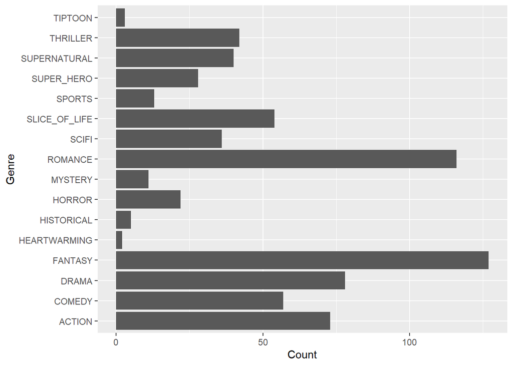

```r
bchart1 <- ggplot(data = webtoons, aes(x = genre)) +
  geom_bar() +
  coord_flip() +
  labs(y = 'Count', x = 'Genre')

bchart1
```

The two dominating categories, fantasy and romance, as well as the next group of popular genres, have broad appeal. This is not too surprising. We must also remember that a single webtoon may encompass more than one genre.

One of the least popular genres is called a “Tiptoon.” These are informative webtoons that the platform sometimes asks its creators to illustrate, giving tips on subjects such as how to stay healthy during the pandemic and how to edit your webtoon. As they are not a regular fictive comic, we will drop the genre.

```r
webtoons <- subset(webtoons, genre != 'TIPTOON')
```

I also suspect budding authors to look at the synopses of established creators in their genres as inspiration. Let’s see if synopsis lengths are generally similar within their genres.

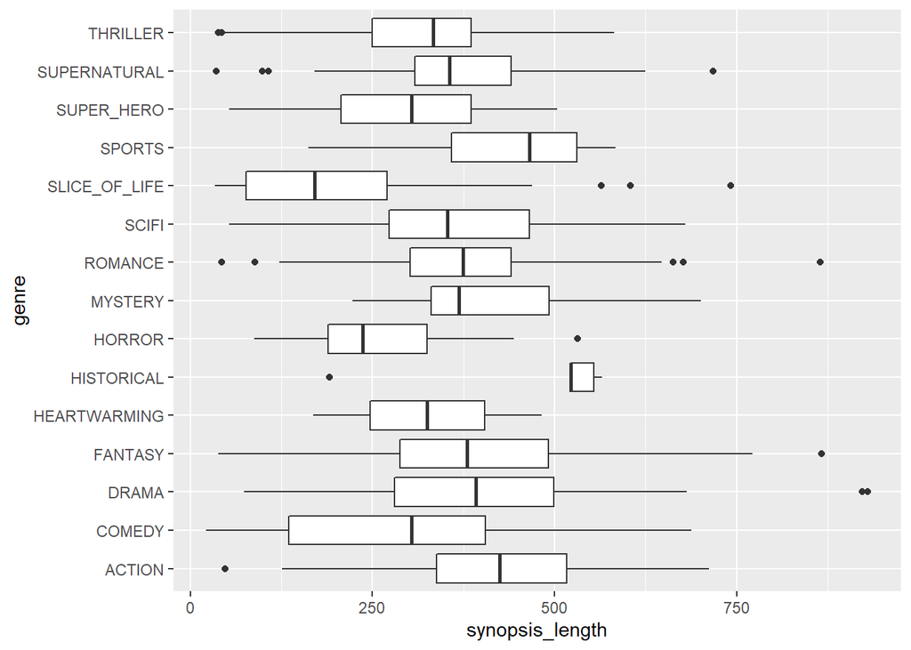

```r
boxplot <- ggplot(webtoons, aes(x=synopsis_length, y=genre)) +
  geom_boxplot()
boxplot
```

Since we do see some fundamental differences in median synopsis length, such as with the slice of life and the historical genres, we will retain `synopsis_length`.

Now let’s look at the distribution of our outcome variable, `style`.

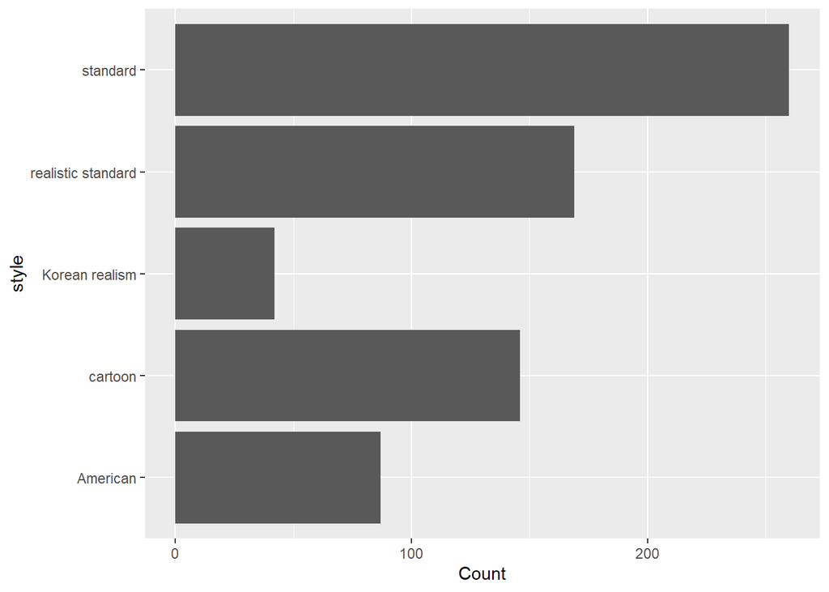

```r
bchart2 <- ggplot(data = webtoons, aes(x = style)) +
  geom_bar() +
  coord_flip() +
  labs(y = 'Count', x = 'style')

bchart2
```

*(The code for setting up the following plot is folded.)*

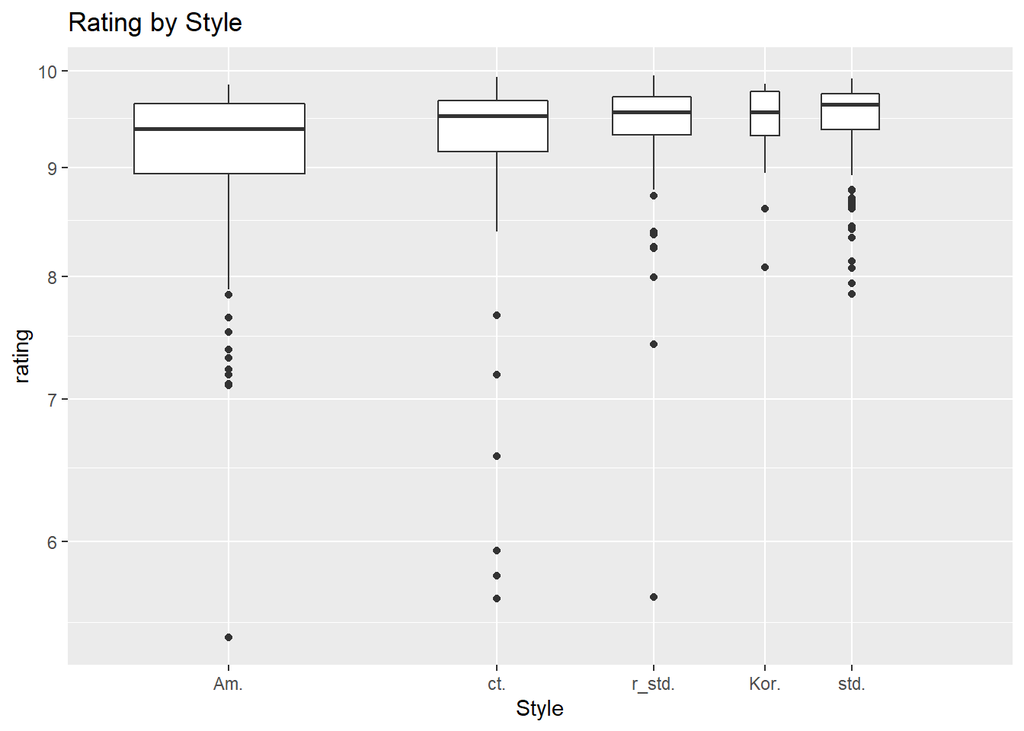

```r
likes_lab <- c('Am.', 'r_std.', 'ct.', 'std.', 'Kor.')
likes_plot <- ggplot(webtoons, aes(reorder(style, likes), likes)) +
  geom_boxplot(varwidth = TRUE) +
  labs(
    title = "Likes by Style",
    x = "Style"
  ) + coord_trans(x = 'log2', y = 'log2') + scale_x_discrete(labels = likes_lab)

views_lab <- c('Am.', 'r_std.', 'ct.', 'std.', 'Kor.')
views_plot <- ggplot(webtoons, aes(reorder(style, views), views)) +
  geom_boxplot(varwidth = TRUE) +
  labs(
    title = "Views by Style",
    x = "Style"
  ) + coord_trans(x = 'log2', y = 'log2') + coord_trans(x = 'log2', y = 'log2') + scale_x_discrete(labels = views_lab)
subs_lab <- c('Am.', 'ct.', 'r_std.', 'std.', 'Kor.')
subs_plot <- ggplot(webtoons, aes(reorder(style, subscribers), subscribers)) +
  geom_boxplot(varwidth = TRUE) +
  labs(
    title = "Subscribers by Style",
    x = "Style"
  ) + coord_trans(x = 'log2', y = 'log2') + scale_x_discrete(labels = subs_lab)

rating_lab <- c('Am.', 'ct.', 'r_std.', 'Kor.', 'std.')
rating_plot <- ggplot(webtoons, aes(reorder(style, rating), rating)) +
  geom_boxplot(varwidth = TRUE) +
  labs(
    title = "Rating by Style",
    x = "Style"
  ) + coord_trans(x = 'log2', y = 'log2') + scale_x_discrete(labels = rating_lab)
rating_plot
```

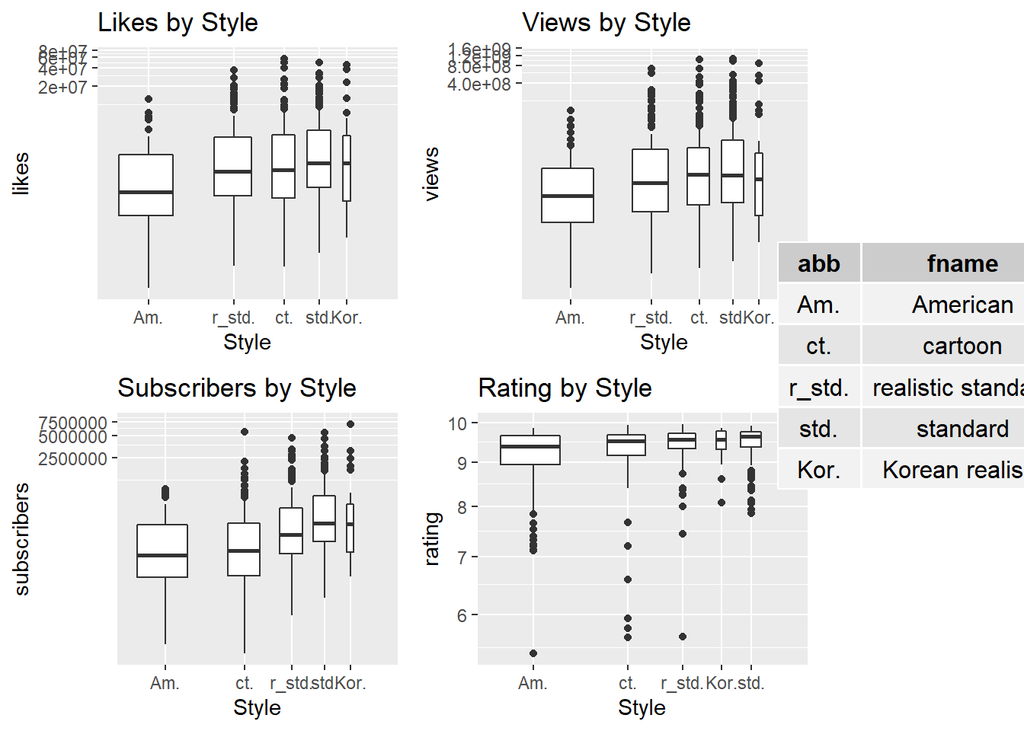

```r
full_name <- data.frame(abb =c('Am.','ct.','r_std.', 'std.', 'Kor.'),fname = c('American','cartoon','realistic standard', 'standard', 'Korean realism'))


square_plot <- ggarrange(likes_plot, views_plot, subs_plot, rating_plot,
          ncol = 2, nrow = 2) +
  theme(axis.text.x = element_text(angle = 90, hjust = 1))

grid.arrange(square_plot, tableGrob(full_name, rows = NULL), nrow = 1, widths = c(4, 1))
```

Interestingly, the American style consistently ranks the lowest, while the others all swap order at some point. This should not come as a surprise, since Webtoons is a Korean platform, so readers may prefer a more Asian style.

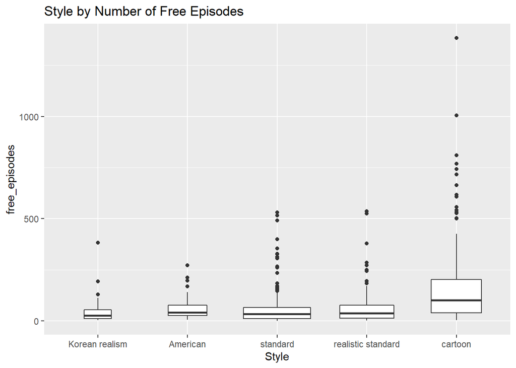

```r
ggplot(webtoons, aes(reorder(style, free_episodes), free_episodes)) +
  geom_boxplot(varwidth = TRUE) +
  labs(
    title = 'Style by Number of Free Episodes',
    x = 'Style'
  )
```

Again, the styles with the most departure from the standard styles—cartoon and American—stand out the most. The American style has a much lower potential ceiling than the rest in terms of free episodes, and the cartoon style has a higher median than every other style’s 75th percentiles.

Let’s see if we can make any other obvious distinctions between styles by comparing each genre’s composition.

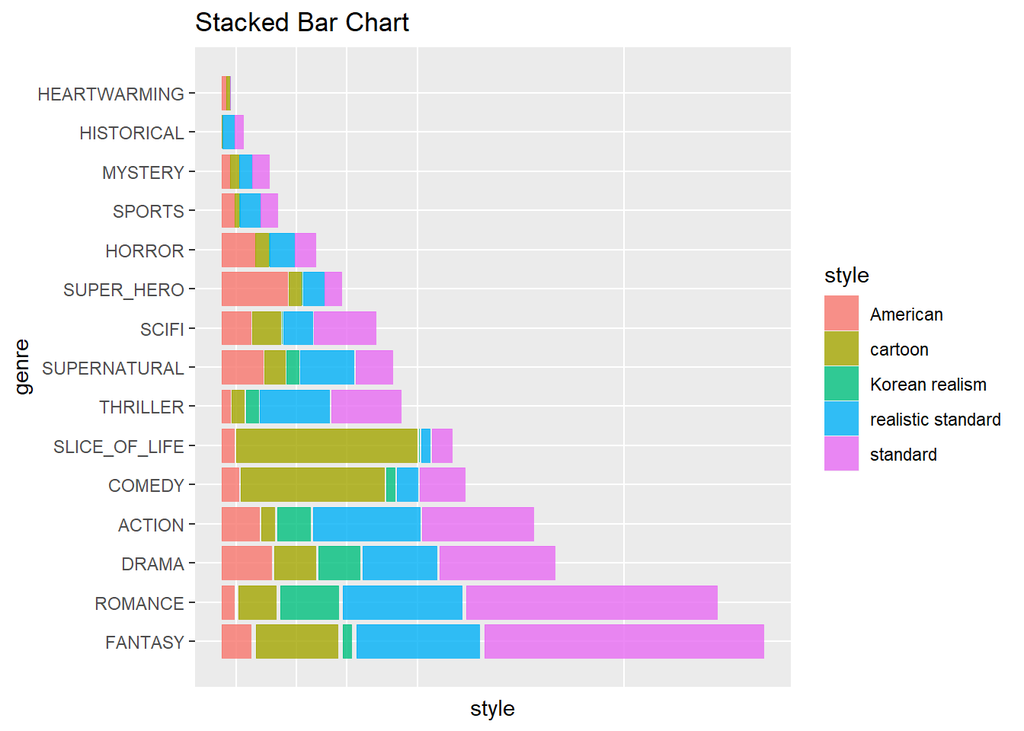

```r
webtoons %>%
  mutate(genre = forcats::fct_infreq(genre)) %>%
ggplot() +
  geom_mosaic(aes(x=product(style, genre), fill = style),
              divider=c('vspine', 'hbar')) +   coord_flip() +
  labs(x='genre', y = 'style', title = 'Stacked Bar Chart') + theme(axis.text.x = element_blank(),
axis.ticks.x = element_blank())
```

Surprisingly, while the American style makes up most of the superhero genre, the superhero genre does not appear to make up most of the American style comics.

We can also see that the bulk of the cartoon styles are in the slice of life and the comedy comics. Hence cartoon is the only style that overwhelmingly dominates any single genre.

# Dummy coding

Quite a few of the variables are not numeric. Now that we’ve explored the data, we will now unpack the categorical variables into more specific ones.

Let’s parse `status`, `original_platform`, `genre`, and the days of the week variables into boolean columns.

- `status`

```r
webtoons <- webtoons %>%
  mutate(n = 1) %>%
  pivot_wider(names_from = status, values_from = n, values_fill = list(n = 0))
```

- `original_platform`

```r
webtoons <- webtoons %>%
  mutate(n = 1) %>%
  pivot_wider(names_from = original_platform, values_from = n, values_fill = list(n = 0))
```

- `genre`

```r
webtoons <- webtoons %>%
  mutate(n = 1) %>%
  pivot_wider(names_from = genre, values_from = n, values_fill = list(n = 0))

# Lowercase all column names
names(webtoons) <- tolower(names(webtoons))
```

- days of the week

```r
webtoons <- cSplit_e(webtoons, 'weekdays', sep = ',', mode = 'binary',
         type = 'character', fill = 0, drop = TRUE)

# renaming
colnames(webtoons)[colnames(webtoons) == 'weekdays_SUNDAY'] <- 'sunday'
colnames(webtoons)[colnames(webtoons) == 'weekdays_MONDAY'] <- 'monday'
colnames(webtoons)[colnames(webtoons) == 'weekdays_TUESDAY'] <- 'tuesday'
colnames(webtoons)[colnames(webtoons) == 'weekdays_WEDNESDAY'] <- 'wednesday'
colnames(webtoons)[colnames(webtoons) == 'weekdays_THURSDAY'] <- 'thursday'
colnames(webtoons)[colnames(webtoons) == 'weekdays_FRIDAY'] <- 'friday'
colnames(webtoons)[colnames(webtoons) == 'weekdays_SATURDAY'] <- 'saturday'
```

- `daily_pass`

```r
webtoons$daily_pass <- ifelse(webtoons$daily_pass == TRUE, 1, 0)
head(webtoons)
```

|  | title | style | free_episodes | subscribers | rating | views | likes | daily_pass | synopsis_length | ongoing | completed | hiatus | korean | english | japanese | indonesian | action | drama | thriller | comedy | supernatural | fantasy | scifi | slice_of_life | romance | super_hero | sports | horror | mystery | … |
| --- | --- | --- | --- | --- | --- | --- | --- | --- | --- | --- | --- | --- | --- | --- | --- | --- | --- | --- | --- | --- | --- | --- | --- | --- | --- | --- | --- | --- | --- | --- |
| 1 | 100 | realistic standard | 13 | 109568 | 9.18 | 827013 | 86431 | 0 | 518 | 1 | 0 | 0 | 1 | 0 | 0 | 0 | 1 | 0 | 0 | 0 | 0 | 0 | 0 | 0 | 0 | 0 | 0 | 0 | 0 | … |
| 2 | 1000 | American | 20 | 104855 | 8.99 | 1444572 | 80168 | 0 | 371 | 0 | 1 | 0 | 0 | 1 | 0 | 0 | 1 | 0 | 0 | 0 | 0 | 0 | 0 | 0 | 0 | 0 | 0 | 0 | 0 | … |
| 3 | #Blessed | American | 64 | 423396 | 9.19 | 19989806 | 1720168 | 0 | 326 | 0 | 0 | 1 | 0 | 1 | 0 | 0 | 0 | 1 | 0 | 0 | 0 | 0 | 0 | 0 | 0 | 0 | 0 | 0 | 0 | … |
| 4 | #Killstagram | realistic standard | 44 | 870587 | 9.32 | 39281698 | 3498815 | 0 | 224 | 0 | 0 | 1 | 1 | 0 | 0 | 0 | 0 | 0 | 1 | 0 | 0 | 0 | 0 | 0 | 0 | 0 | 0 | 0 | 0 | … |
| 5 | 10th Dimension Boys | cartoon | 119 | 93215 | 9.34 | 27986110 | 801533 | 0 | 135 | 0 | 1 | 0 | 0 | 1 | 0 | 0 | 0 | 0 | 0 | 1 | 0 | 0 | 0 | 0 | 0 | 0 | 0 | 0 | 0 | … |
| 6 | 11 of Me | American | 7 | 102268 | 8.83 | 1407074 | 195701 | 1 | 355 | 0 | 1 | 0 | 1 | 0 | 0 | 0 | 0 | 0 | 0 | 0 | 1 | 0 | 0 | 0 | 0 | 0 | 0 | 0 | 0 | … |

# Factors

Now we will convert our categorial variables into factors.

- `style` and `daily_pass`

```r
webtoons$style <- as.factor(webtoons$style)
webtoons$daily_pass <- as.factor(webtoons$daily_pass)
```

- platforms

```r
webtoons$english <- as.factor(webtoons$english)
webtoons$korean <- as.factor(webtoons$korean)
webtoons$japanese <- as.factor(webtoons$japanese)
webtoons$indonesian <- as.factor(webtoons$indonesian)
```

- genres

```r
webtoons$action <- as.factor(webtoons$action)
webtoons$comedy <- as.factor(webtoons$comedy)
webtoons$drama <- as.factor(webtoons$drama)
webtoons$fantasy <- as.factor(webtoons$fantasy)
webtoons$heartwarming <- as.factor(webtoons$heartwarming)
webtoons$historical <- as.factor(webtoons$historical)
webtoons$horror <- as.factor(webtoons$horror)
webtoons$mystery <- as.factor(webtoons$mystery)
webtoons$romance <- as.factor(webtoons$romance)
webtoons$slice_of_life <- as.factor(webtoons$slice_of_life)
webtoons$scifi <- as.factor(webtoons$scifi)
webtoons$sports <- as.factor(webtoons$sports)
webtoons$super_hero <- as.factor(webtoons$super_hero)
webtoons$supernatural <- as.factor(webtoons$supernatural)
webtoons$thriller <- as.factor(webtoons$thriller)
```

- statuses

```r
webtoons$ongoing <- as.factor(webtoons$ongoing)
webtoons$completed <- as.factor(webtoons$completed)
webtoons$hiatus <- as.factor(webtoons$hiatus)
```

- days of the week

```r
webtoons$monday <- as.factor(webtoons$monday)
webtoons$tuesday <- as.factor(webtoons$tuesday)
webtoons$tuesday <- as.factor(webtoons$tuesday)
webtoons$wednesday <- as.factor(webtoons$wednesday)
webtoons$thursday <- as.factor(webtoons$thursday)
webtoons$friday <- as.factor(webtoons$friday)
webtoons$saturday <- as.factor(webtoons$saturday)
webtoons$sunday <- as.factor(webtoons$sunday)
```

# Model setup

## Data Split

We will allocate 80% of the data to the training set and 20% to the testing set.

```r
set.seed(66)
w_split <- initial_split(webtoons, prop = 0.8, strata = 'style')
w_train <- training(w_split)
w_test <- testing(w_split)
```

- Here I will check that the data are split in correct percentages.

```r
dim(w_train)
```

[output not shown]

```r
dim(w_test)
```

[output not shown]

```r
dim(webtoons)
```

[output not shown]

## Folding data

Now we will perform v-fold cross validation with 10 folds, stratifying by `style`.

```r
w_folds <- vfold_cv(data = w_train, v = 10, strata = 'style')
```

## Recipe

Setting up recipe to predict `style`:

```r
w_recipe <- recipe(style ~ rating + views  + daily_pass + free_episodes  + likes + subscribers + synopsis_length + monday + tuesday + wednesday + thursday + friday + saturday + sunday + ongoing + completed + hiatus + english + korean + japanese + indonesian + action + comedy + drama + fantasy + heartwarming + historical + horror + mystery + romance + scifi + slice_of_life + sports + super_hero + supernatural + thriller,
                   data = w_train) %>%
  step_dummy(c(daily_pass, monday, tuesday, wednesday, thursday, friday, saturday, sunday, ongoing, completed, hiatus, english, korean, japanese, indonesian, action, comedy, drama, fantasy, heartwarming, historical, horror, mystery, romance, scifi, slice_of_life, sports, super_hero, supernatural, thriller)) %>%
  step_normalize(all_predictors())
```

# Modeling

I decided to run the following models thanks to my dataset being dominated by categorical variables:

- multinomial logistic regression
- random forest
- boosted trees
- decision tree
- nearest neighbors

## Multinomial logistic regression

We will tune `penalty` and `mixture`. Since our outcome is `style`, `mode` is set to `classification`.

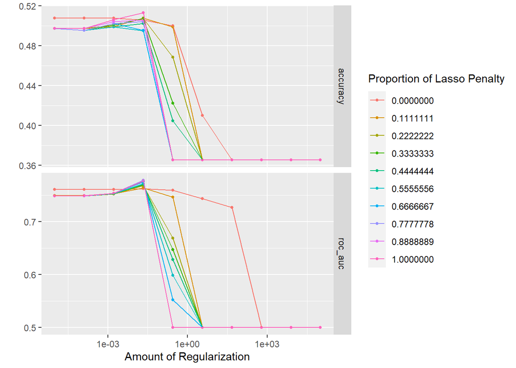

```r
multinom_mod <- multinom_reg(penalty = tune(),
                        mixture = tune()) %>%
  set_engine('glmnet') %>%
  set_mode('classification')

multinom_wkflow = workflow() %>%
  add_model(multinom_mod) %>%
  add_recipe(w_recipe)

multinom_grid = grid_regular(penalty(range = c(-5, 5)),
                       mixture(range = c(0, 1)),
                       levels = 10)

multinom_tune <- tune_grid(object = multinom_wkflow,
                        resamples = w_folds,
                        grid = multinom_grid)

autoplot(multinom_tune)
```

## Random forest

```r
rf_mod <-
  rand_forest(min_n = tune(), mtry = tune()) %>%
  set_mode('classification') %>%
  set_engine('randomForest')

rf_wkflow <- workflow() %>%
  add_model(rf_mod) %>%
  add_recipe(w_recipe)

rf_grid <- grid_regular(min_n(),
                        mtry(range = c(1, 35)),
                        levels = 3)

rf_tune <- rf_wkflow %>%
  tune_grid(resamples = w_folds,
    grid = rf_grid)

rf_tune %>% collect_metrics() %>%
  select(-.estimator, -.config)
```

| mtry | min_n | .metric | mean | n | std_err |
| --- | --- | --- | --- | --- | --- |
| 1 | 2 | accuracy | 0.4561889 | 10 | 0.009684991 |
| 1 | 2 | roc_auc | 0.7335608 | 10 | 0.012256413 |
| 1 | 21 | accuracy | 0.4506749 | 10 | 0.009760841 |
| 1 | 21 | roc_auc | 0.7261637 | 10 | 0.015778031 |
| 1 | 40 | accuracy | 0.4543382 | 10 | 0.008582009 |
| 1 | 40 | roc_auc | 0.7211867 | 10 | 0.013203628 |
| 18 | 2 | accuracy | 0.4958946 | 10 | 0.017426887 |
| 18 | 2 | roc_auc | 0.7644172 | 10 | 0.009143496 |
| 18 | 21 | accuracy | 0.5083429 | 10 | 0.013972057 |
| 18 | 21 | roc_auc | 0.7619591 | 10 | 0.009618957 |

[output cut: 8 more lines]

# Boosted trees

```r
boost_mod <- boost_tree(trees = tune()) %>%
  set_engine('xgboost') %>%
  set_mode('classification')

boost_wkflow <- workflow() %>%
  add_model(boost_mod) %>%
  add_recipe(w_recipe)

boost_grid <- grid_regular(trees(c(60,140)),
                           levels = 3)

tune_boost <- tune_grid(
  boost_wkflow,
  resamples = w_folds,
  grid = boost_grid
)

tune_boost %>% collect_metrics() %>%
  select(-.estimator, -.config)
```

| trees | .metric | mean | n | std_err |
| --- | --- | --- | --- | --- |
| 60 | accuracy | 0.4851792 | 10 | 0.01530679 |
| 60 | roc_auc | 0.7361103 | 10 | 0.01452558 |
| 100 | accuracy | 0.4744000 | 10 | 0.01743863 |
| 100 | roc_auc | 0.7299665 | 10 | 0.01432919 |
| 140 | accuracy | 0.4798221 | 10 | 0.01940533 |
| 140 | roc_auc | 0.7271865 | 10 | 0.01396822 |

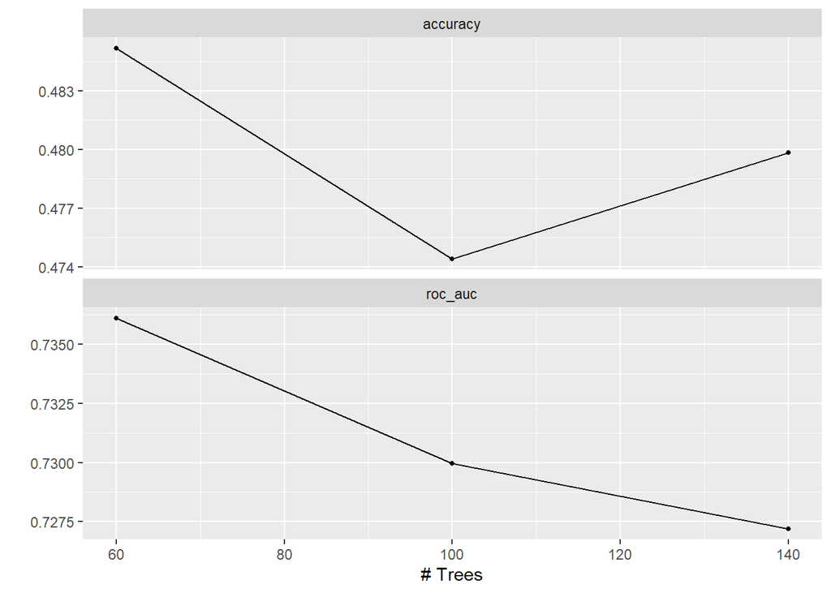

```r
autoplot(tune_boost)
```

# Decision tree

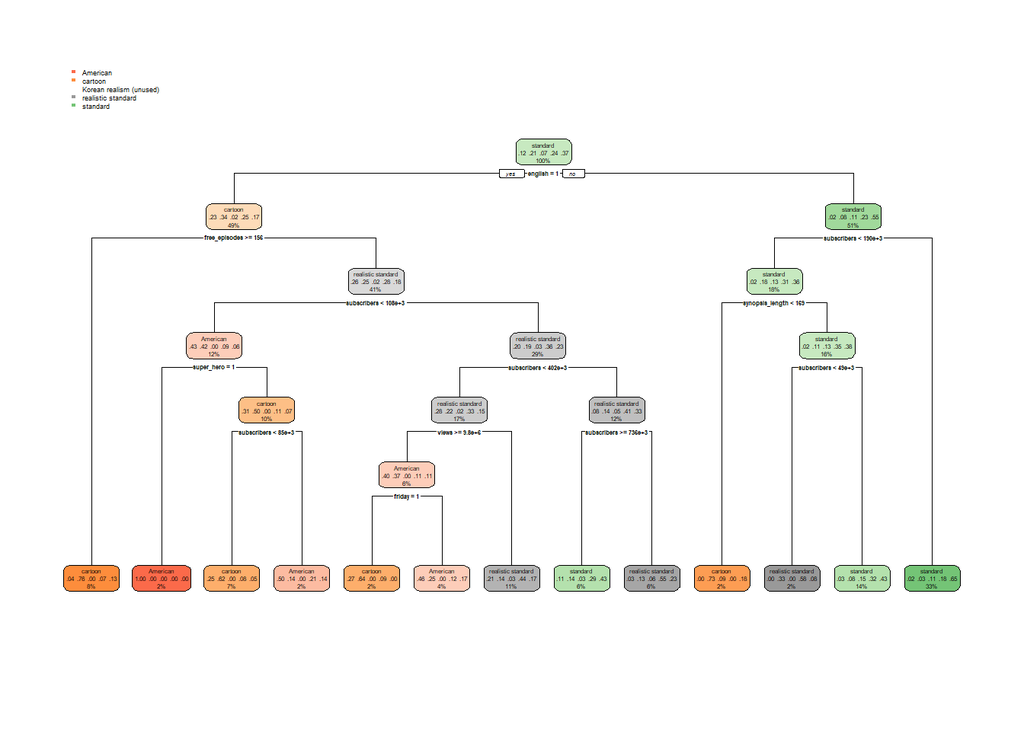

```r
tree_mod <- decision_tree() %>%
  set_engine('rpart')

tree_spec <- tree_mod %>%
  set_mode('classification')

tree_fit <- tree_spec %>%
  fit(style ~ rating + views  + daily_pass + free_episodes  + likes + subscribers + synopsis_length + monday + tuesday + wednesday + thursday + friday + saturday + sunday + ongoing + completed + hiatus + english + korean + indonesian + action + comedy + drama + fantasy + heartwarming + historical + horror + mystery + romance + scifi + slice_of_life + sports + super_hero + supernatural + thriller,
                   data = w_train) %>%
  step_dummy(c(daily_pass, monday, tuesday, wednesday, thursday, friday, saturday, sunday, ongoing, completed, hiatus, english, korean, indonesian, action, comedy, drama, fantasy, heartwarming, historical, horror, mystery, romance, scifi, slice_of_life, sports, super_hero, supernatural, thriller)) %>%
  step_normalize(all_predictors())

tree_fit %>%
  extract_fit_engine() %>%
  rpart.plot(roundint = FALSE)
```

```r
augment(tree_fit, new_data = w_train) %>%
  accuracy(truth = style, estimate = .pred_class)
```

| .metric | .estimator | .estimate |
| --- | --- | --- |
| accuracy | multiclass | 0.5793226 |

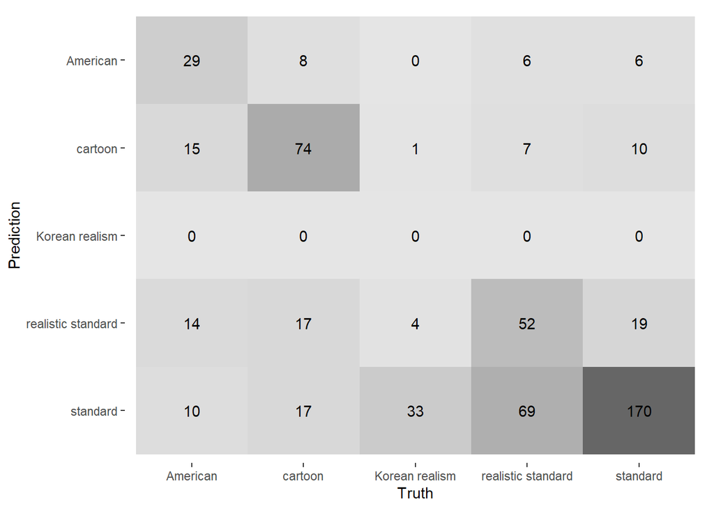

```r
augment(tree_fit, new_data = w_train) %>%
  conf_mat(truth = style, estimate = .pred_class) %>%
  autoplot(type = 'heatmap')
```